# Students Data Analysis

## Data setup

Setup your working directory:

```r
setwd("C:/Users/farre/Desktop/students")
```

The import, cleaning, and separation processes are all applied in the following line. To see the details of what’s happening take a look at the `import.R` and `clean.R` files, but generally we’re importing the CSV without converting string variables into vectors, then we do the following:

1. Convert invalid values (e.g. 0, 48) to NAs
2. Impute NAs using the most common value for a variable
3. Convert ordinal variables were appropriate
4. Convert categorical variables were appropriate
5. Collapse categories in `SAT_*` variables into two groups

```r
data <- clean(import("./data/data.csv"))
```

```
## [1] "No. observations initial: 648"
## [1] "Imputed 0 for ID"
## [1] "Imputed 4 for SEX"
## [1] "Imputed 2 for AGE"
## [1] "Imputed 7 for ENG_FIRST"
## [1] "Imputed 12 for DISTANCE"
## [1] "Imputed 10 for HS_GPA"
## [1] "Imputed 158 for SAT_Verbal"
## [1] "Imputed 153 for SAT_Math"
## [1] "Imputed 366 for ACTCOMP"
## [1] "Imputed 2 for CITIZEN"
## [1] "Imputed 2 for PARSTAT"
## [1] "Imputed 56 for INCOME"
## [1] "Imputed 6 for FINCON"
## [1] "Imputed 17 for SRELIGION"
```

[output cut: 131 more lines]

To help reduce the impact of such imbalance we do two things. We use Synthetic Minority Over-sampling TEchnique (SMOTE) to oversample the minority class and undersample the majority class, which will produce a more balanced dataset. The following code shows the difference in the proportions before and after the re-sampling technique is used.

Category proportions for each dependent before balancing:

```r
category_proportions(data, "SAT_OVERALL")
```

```
##
## Dissatisfied/Neutral            Satisfied
##           0.09104938           0.90895062
## [1] "No. of observations: 648"
```

```r
category_proportions(data, "SAT_COMMUNITY")
```

```
##
## Dissatisfied/Neutral            Satisfied
##           0.09259259           0.90740741
## [1] "No. of observations: 648"
```

```r
category_proportions(data, "SAT_INSTRUCTION")
```

```
##
## Dissatisfied/Neutral            Satisfied
##           0.04166667           0.95833333
## [1] "No. of observations: 648"
```

Mosaic graphs for each dependent before balancing:

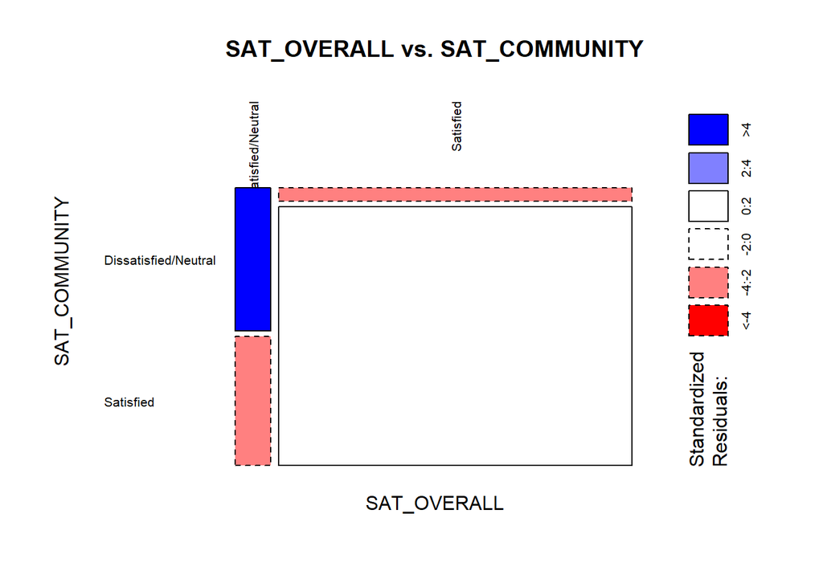

```r
mosaic(data, "SAT_OVERALL", "SAT_COMMUNITY")
```

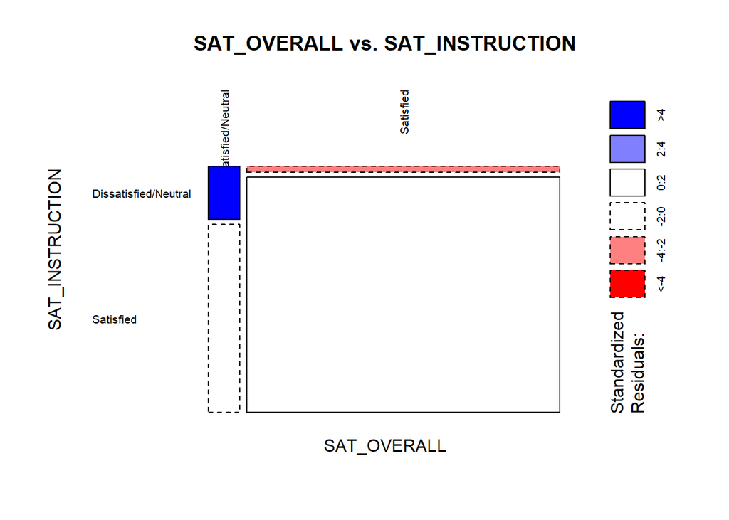

```r
mosaic(data, "SAT_OVERALL", "SAT_INSTRUCTION")
```

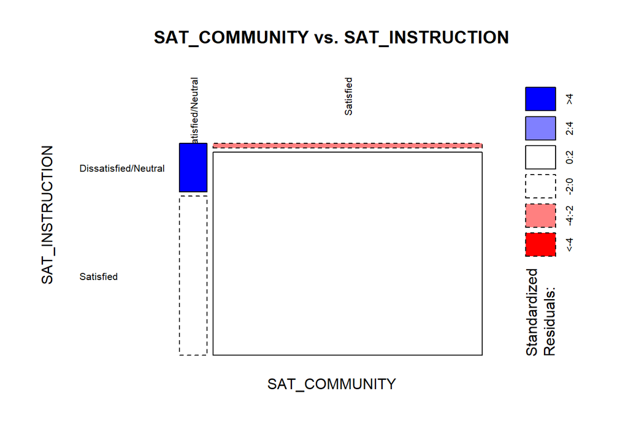

```r
mosaic(data, "SAT_COMMUNITY", "SAT_INSTRUCTION")
```

Balloon graphs for each dependent before balancing:

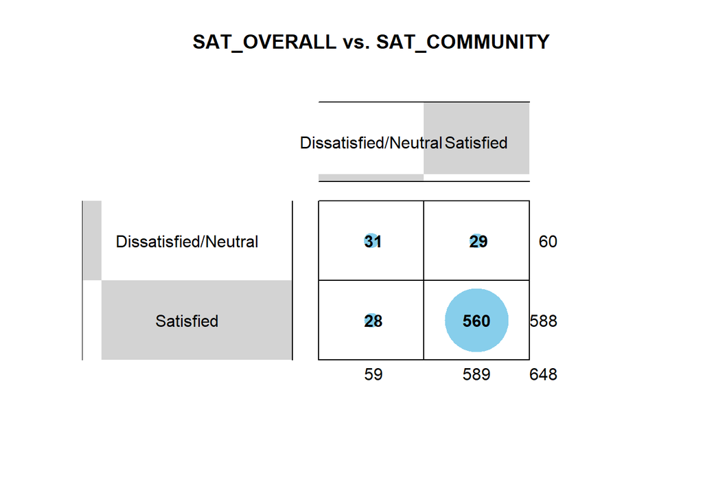

```r
balloon(data, "SAT_OVERALL", "SAT_COMMUNITY")
```

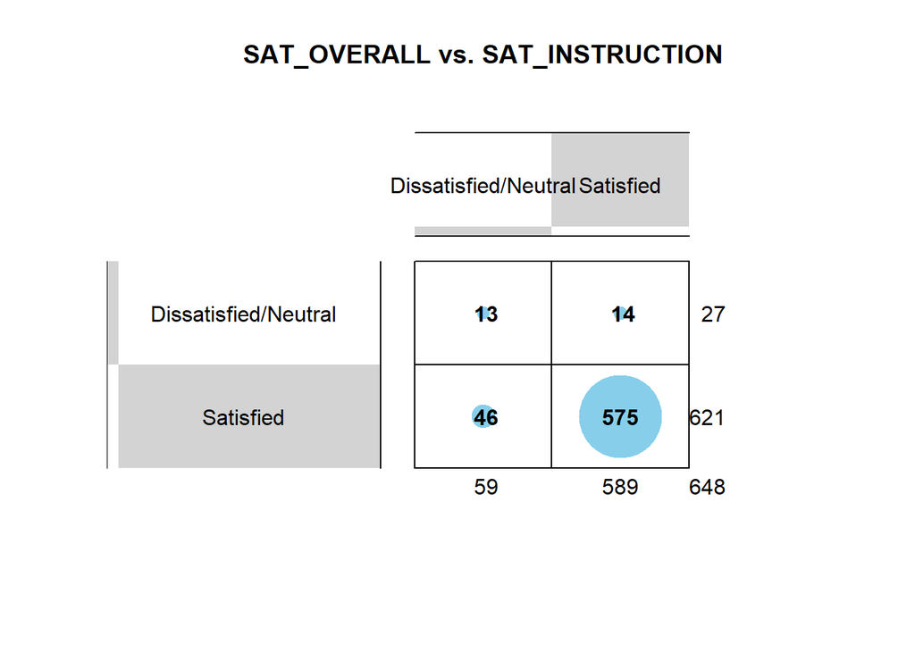

```r
balloon(data, "SAT_OVERALL", "SAT_INSTRUCTION")
```

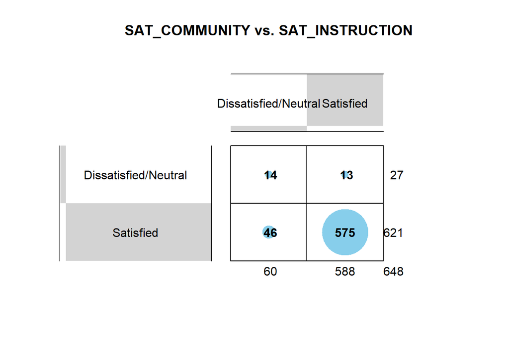

```r
balloon(data, "SAT_COMMUNITY", "SAT_INSTRUCTION")
```

Balance the data:

```r
data <- balance(data)
```

Category proportions for each dependent after balancing:

```r
category_proportions(data, "SAT_OVERALL")
```

```
##
## Dissatisfied/Neutral            Satisfied
##            0.3989218            0.6010782
## [1] "No. of observations: 742"
```

```r
category_proportions(data, "SAT_COMMUNITY")
```

```
##
## Dissatisfied/Neutral            Satisfied
##             0.416442             0.583558
## [1] "No. of observations: 742"
```

```r
category_proportions(data, "SAT_INSTRUCTION")
```

```
##
## Dissatisfied/Neutral            Satisfied
##            0.4285714            0.5714286
## [1] "No. of observations: 742"
```

Mosaic graphs for each dependent after balancing:

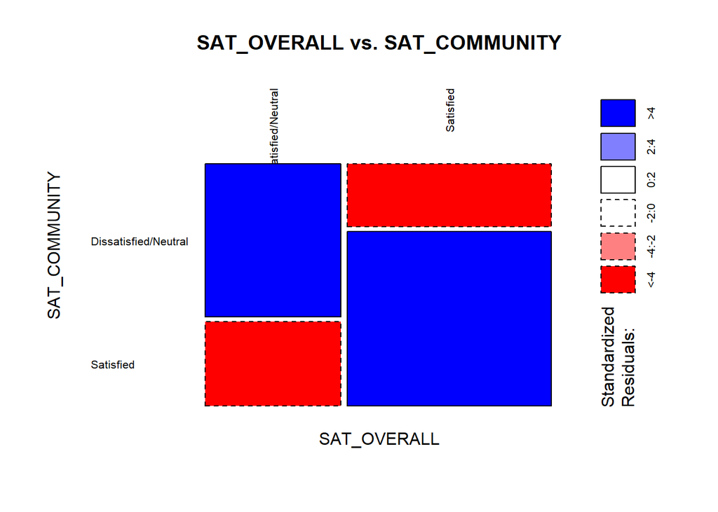

```r
mosaic(data, "SAT_OVERALL", "SAT_COMMUNITY")
```

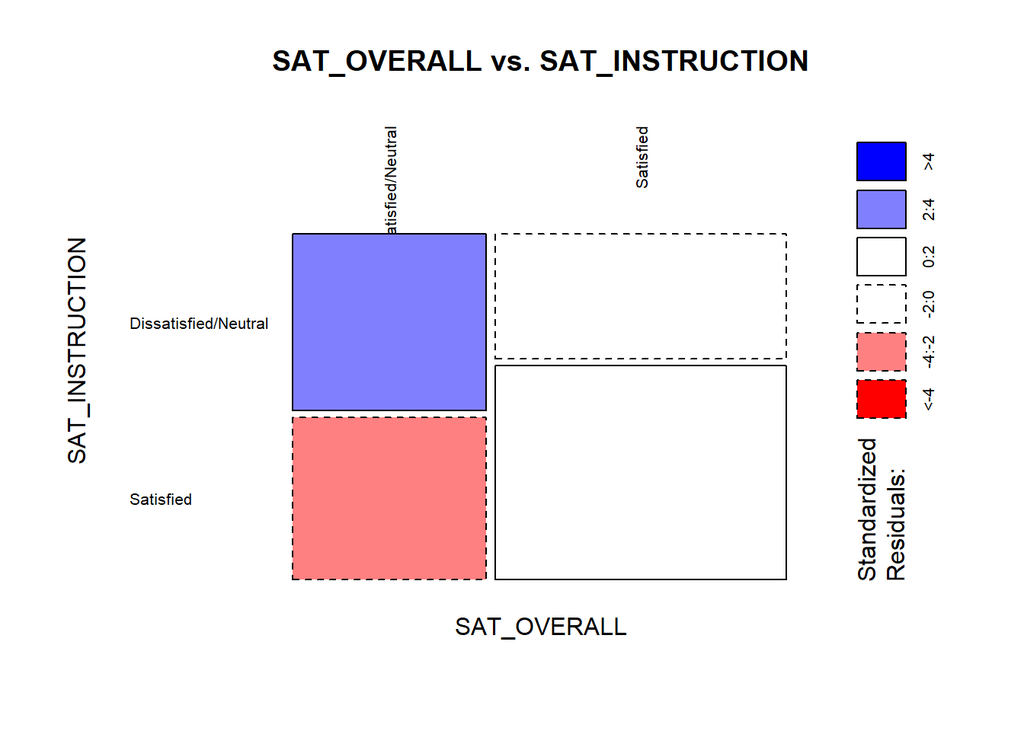

```r
mosaic(data, "SAT_OVERALL", "SAT_INSTRUCTION")
```

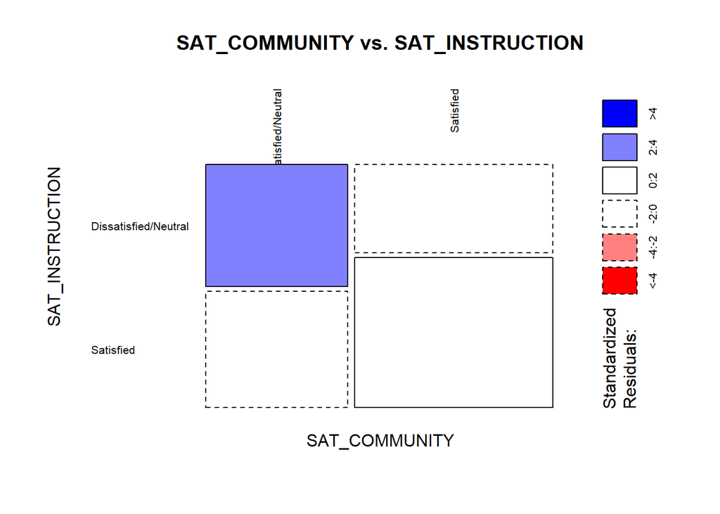

```r
mosaic(data, "SAT_COMMUNITY", "SAT_INSTRUCTION")
```

Balloon graphs for each dependent after balancing:

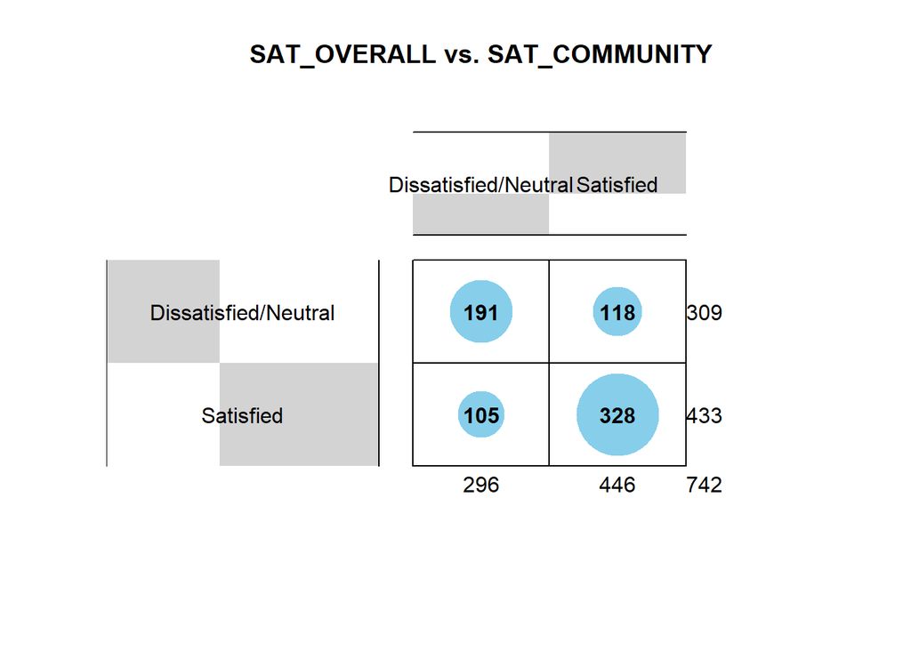

```r
balloon(data, "SAT_OVERALL", "SAT_COMMUNITY")
```

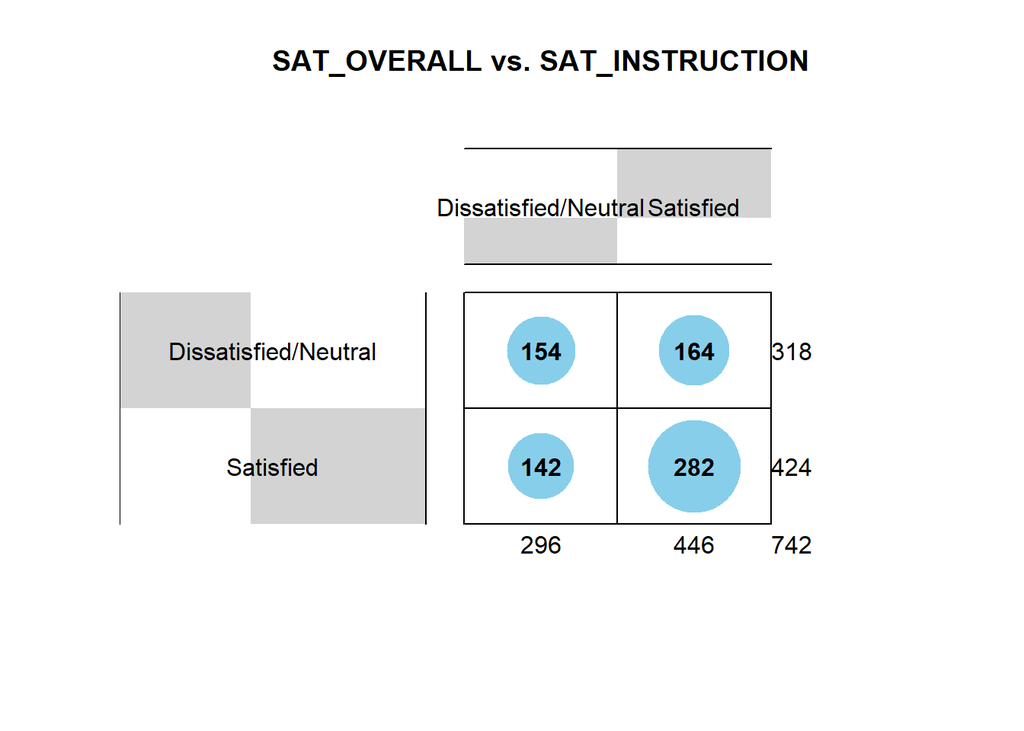

```r
balloon(data, "SAT_OVERALL", "SAT_INSTRUCTION")
```

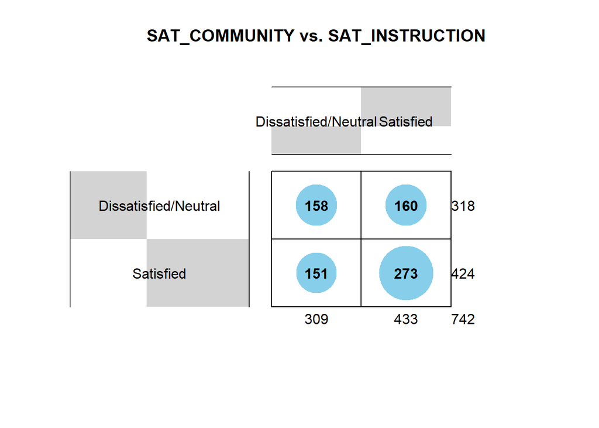

```r
balloon(data, "SAT_COMMUNITY", "SAT_INSTRUCTION")
```

When sampling data for our training and testing data sets, we apply stratified sampling to make sure we keep the proportions reached by the SMOTE technique while creating the two data subsets (`train` and `test`), plus the original one saved in the `full` attribute. To access the three different datasets we created (i.e. `full`, `train`, and `test`) you can access the respective elements of the `data` object as shown in the examples below.

```r
data <- separate(data)
```

Some examples of how to interact with this object are shown below (wihtout output):

```r
nrow(data[["full"]])
nrow(data[["train"]])
nrow(data[["test"]])

head(data[["full"]])
names(data[["full"]])
summary(data[["full"]])
```

## Visualizations

Since almost all variables are categorical, we don’t have too much room to play with with visualizations, but we use two main types of graphs: mosaics and correspondence analysis. Mosaic graphs allow us to visualize the conditional distributions in the data we’re analyzing, and to understand where subgroups are deviating from the implied random distributions. Correspondence analysis helps understand the relationships among the variable values. It’s similar to Principal Component Analysis (PCA) but focuses on relative rather than absolute differences, which is what we want in this case to understand relative distributions, which helps for variable selection.

For the mosaic graphs, the area of the mosaic reflects the relative magnitude of the values. Blue colors indicate observed values are higher than expected values, if the data were random. Red colors indicate observed values are lower than expected values, if the data were random.

The the correspondence analysis, all the blue values correspond to one variable, and the red ones to the other. The closer they are in the graph, the more likely they occur together in the data, and viceversa. Keep in mind that thes graphs will only be created when there are at least three categories for each of the two categorical variables used in each case. This is a requirements of the correspondence analysis.

There are lots of combinations to try, so we automate the process of creating all of the possible combinations and saving the graphs to disk so that it’s easier to go through them using the operating system’s image explorer (look for them in side the `graphs/` directory). There are interesting findings when going through those graphs.

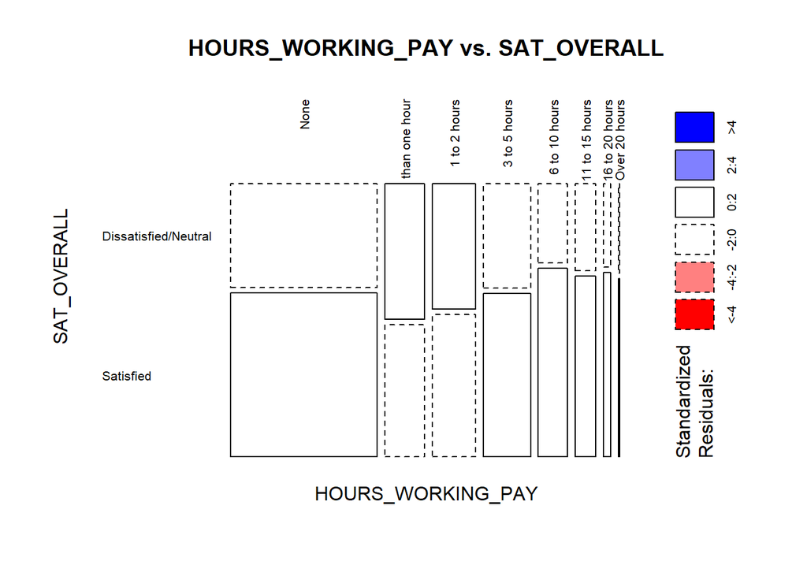

```r
mosaic(data, "HOURS_WORKING_PAY", "SAT_OVERALL")
```

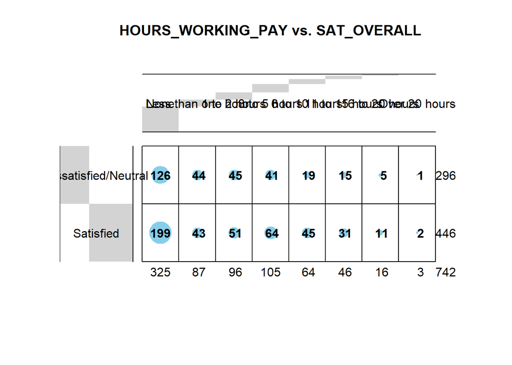

```r
balloon(data, "HOURS_WORKING_PAY", "SAT_OVERALL")
```

```r
correspondence(data, "HOURS_WORKING_PAY", "SAT_OVERALL")
```

```
## [1] "Warning: could not create correspondence graph for: HOURS_WORKING_PAY / SAT_OVERALL (see original error below)"
## <simpleError in if (max(axes) > ndim) stop("The value of the argument axes is incorrect. ",     "The number of axes in the data is: ", ncol(elmt$coord),     ". Please try again with axes between 1 - ", ncol(elmt$coord)): argument is of length zero>
```

> **CAUTION**: Executing these lines can take a long time because there are thousands of graphs being created for each of the three types of graphs. The way this document is configured they will not be executed to avoid any accidents.

```r
create_and_save_all_graphs(data, "correspondence")
create_and_save_all_graphs(data, "balloon")
create_and_save_all_graphs(data, "mosaic")
```

## Variable selection

Variable selection is performed with Recursive Feature Elimination (RFE). The `selection_*` objects contain the following attributes: `data` which is the data with the variable selection applied, `graph` which shows the accuracy change as more variables are added, `n_variables` which is the number of variables selected, and `variables` which are the variables actually selected. Internally, Random Forests are used to measure variable importance.

The selection for the “community” and “instruction” dependent variables can be accomplished with the following code (which is not actually run because it will not be used in this document, but is left as reference):

```r
selection_instruction <- variable_selection(data, "SAT_INSTRUCTION")
selection_community <- variable_selection(data, "SAT_COMMUNITY")
```

To explore the results for the selection for “overall”, you can use the following to see the filtered datasets, variables, and optimization graph. The output is not shown to preserve space, but each of those would show the first couple of rows of each dataset (train, test, and full).

```r
head(selection_overall[["data"]][["full"]])
head(selection_overall[["data"]][["train"]])
head(selection_overall[["data"]][["test"]])
```

To see the variables found to be the ones with the most predictive power, we can use the following code, which shows the number of variables and the variable names themselves.

```r
selection_overall[["n_variables"]]
```

```
## [1] 110
```

```r
selection_overall[["variables"]]
```

```
##   [1] "MCAREER"
##   [2] "FCAREER"
##   [3] "SCAREER"
##   [4] "FRELIGION"
##   [5] "SAT_COMMUNITY"
##   [6] "MRELIGION"
##   [7] "SRELIGION"
##   [8] "SAT_Verbal"
##   [9] "INCOME"
##  [10] "SAT_Math"
##  [11] "W_C"
##  [12] "HOURS_READING"
##  [13] "ACT_DISCUSS_RELIG"
##  [14] "ID"
##  [15] "SELF_RATING_SPIRITUALITY"
```

[output cut: 95 more lines]

To see a graph of how the predictive accuracy changes as we add more variables, we can look at the following graph. The filled dot corresponds to the selected case.

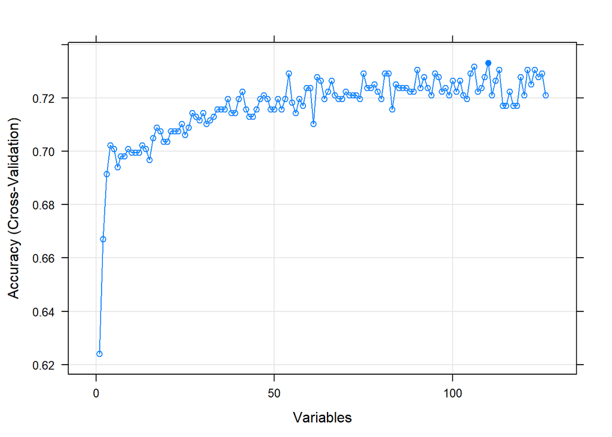

```r
selection_overall[["graph"]]
```

## Model application

> *At times, model application becomes problematic because there’s a very low number of observations per year for some samples. To avoid that problem, I’m currently setting the `YEAR_FS` value to `ALL` for all observations, we can relax this later to test what recategorization makes more sense.*

```r
val <- "ALL"
var <- "YEAR_FS"
data <- recode_variable(data, var, val)
selection_overall[["data"]] <- recode_variable(
    selection_overall[["data"]], var, val
)
```

The same goes for the other dependents (which we are not using in this document, so their code will not be executed).

```r
selection_community[["data"]] <- recode_variable(
    selection_community[["data"]], var, val
)
selection_instruction[["data"]] <- recode_variable(
    selection_instruction[["data"]], var, val
)
```

To specify which models we want to use we use the following. The first string (e.g. “random_forest”) is an identifier created by us to know what model we’re working with, and the second string (e.g. “rf”) is an ID for the model we want to use that is recognized by the `caret` package. Feel free to add other models, you can find the full list here: https://topepo.github.io/caret/available-models.html

> These models depend on external packages. If you don’t have installed in your system, when you execute the code, you’ll be notified that you don’t have them, and you’ll be asked whether you want to install them. If you do, execution will continue normally after the corresponding installations.

```r
models <- list(
    "random_forest" = "rf",
    "support_vector_machine" = "svmRadial",
    "naive_bayes" = "naive_bayes"
)
```

We now proceed to find the best model for each year with cross-validation:

```r
overall_results <- best_results_per_year(
    selection_overall[["data"]],
    "SAT_OVERALL",
    models
)
```

```
## [1] "- ALL"
## [1] "    - random_forest"
## [1] "    - support_vector_machine"
```

```
## [1] "    - naive_bayes"
```

To accomplish the same for the other dependents, we can use the following code, which is not actually executed in this document as we will not use its results.

```r
community_results <- best_results_per_year(
    selection_community[["data"]],
    "SAT_COMMUNITY",
    models
)
instruction_results <- best_results_per_year(
    selection_instruction[["data"]],
    "SAT_INSTRUCTION",
    models
)
```

## Results exploration

To explore other years, you should change the `Y_ALL` value to other years. Note that we had to use the `Y_` prefix because R does not allow for names to start with numbers. You can similarly explore other dependent variables or models. These are just some examples.

To compare the predictive power, you may want to look at the predictive power of each model for each year and for each dependent variable. You can find these values in the `metrics` attribute in each case.

Note that in some cases there may be no variable importance information (it depends on whether or not the model used is able to produce it), and there may also not be a ROC curve to show (in the case were the sample did not have at least one case for one of the categories). To fix this last case we would have to use stratified-sampling.

Years available:

```r
names(overall_results)
```

```
## [1] "Y_ALL"
```

Models available for a given year:

```r
names(overall_results[["Y_ALL"]])
```

```
## [1] "random_forest"          "support_vector_machine"
## [3] "naive_bayes"
```

Result objects available for year/model selection:

```r
names(overall_results[["Y_ALL"]][["random_forest"]])
```

```
## [1] "metrics"    "graph"      "predictor"  "importance"
```

See the `predictor` object, for a given year and Random Forest:

```r
overall_results[["Y_ALL"]][["random_forest"]][["predictor"]]
```

```
## Random Forest
##
## 521 samples
## 106 predictors
##   2 classes: 'Dissatisfied/Neutral', 'Satisfied'
##
## No pre-processing
## Resampling: Cross-Validated (2 fold)
## Summary of sample sizes: 261, 260
## Addtional sampling using SMOTE
##
## Resampling results across tuning parameters:
##
##   mtry  Accuracy   Kappa
##     2   0.7274388  0.3905245
##    32   0.7466254  0.4579000
##   534   0.7024831  0.3649252
##
## Accuracy was used to select the optimal model using the largest value.
## The final value used for the model was mtry = 32.
```

The results I’m seeing in average are the following. Note that these may be different every time you run the analysis because we’re not controlling the “seed” for the randomized algorithmns (this is done on purpose to see variuos results, but for publishing or sharing results with someone else, we should control the seed).

| Model | Accuracy | Kappa |
| --- | --- | --- |
| Support Vector Machine | 0.6637 | 0.3274 |
| Random Forest | 0.7876 | 0.5752 |
| Naive Bayes | 0.6327 | 0.2655 |

```r
overall_results[["Y_ALL"]][["support_vector_machine"]][["metrics"]]
```

```
## Confusion Matrix and Statistics
##
##                       Reference
## Prediction             Dissatisfied/Neutral Satisfied
##   Dissatisfied/Neutral                   54        25
##   Satisfied                              34       108
##
##                Accuracy : 0.733
##                  95% CI : (0.6696, 0.7901)
##     No Information Rate : 0.6018
##     P-Value [Acc > NIR] : 3.021e-05
##
##                   Kappa : 0.4332
##  Mcnemar's Test P-Value : 0.2976
##
##             Sensitivity : 0.6136
##             Specificity : 0.8120
##          Pos Pred Value : 0.6835
##          Neg Pred Value : 0.7606
##              Prevalence : 0.3982
##          Detection Rate : 0.2443
##    Detection Prevalence : 0.3575
##       Balanced Accuracy : 0.7128
##
##        'Positive' Class : Dissatisfied/Neutral
##
```

```r
overall_results[["Y_ALL"]][["random_forest"]][["metrics"]]
```

```
## Confusion Matrix and Statistics
##
##                       Reference
## Prediction             Dissatisfied/Neutral Satisfied
##   Dissatisfied/Neutral                   57        12
##   Satisfied                              31       121
##
##                Accuracy : 0.8054
##                  95% CI : (0.747, 0.8555)
##     No Information Rate : 0.6018
##     P-Value [Acc > NIR] : 7.359e-11
##
##                   Kappa : 0.5786
##  Mcnemar's Test P-Value : 0.006052
##
##             Sensitivity : 0.6477
##             Specificity : 0.9098
##          Pos Pred Value : 0.8261
##          Neg Pred Value : 0.7961
##              Prevalence : 0.3982
##          Detection Rate : 0.2579
##    Detection Prevalence : 0.3122
##       Balanced Accuracy : 0.7788
##
##        'Positive' Class : Dissatisfied/Neutral
##
```

```r
overall_results[["Y_ALL"]][["naive_bayes"]][["metrics"]]
```

```
## Confusion Matrix and Statistics
##
##                       Reference
## Prediction             Dissatisfied/Neutral Satisfied
##   Dissatisfied/Neutral                    4         0
##   Satisfied                              84       133
##
##                Accuracy : 0.6199
##                  95% CI : (0.5524, 0.6842)
##     No Information Rate : 0.6018
##     P-Value [Acc > NIR] : 0.3166
##
##                   Kappa : 0.0542
##  Mcnemar's Test P-Value : <2e-16
##
##             Sensitivity : 0.04545
##             Specificity : 1.00000
##          Pos Pred Value : 1.00000
##          Neg Pred Value : 0.61290
##              Prevalence : 0.39819
##          Detection Rate : 0.01810
##    Detection Prevalence : 0.01810
##       Balanced Accuracy : 0.52273
##
##        'Positive' Class : Dissatisfied/Neutral
##
```

See the “optimization” `graph`, for a given year and Random Forest:

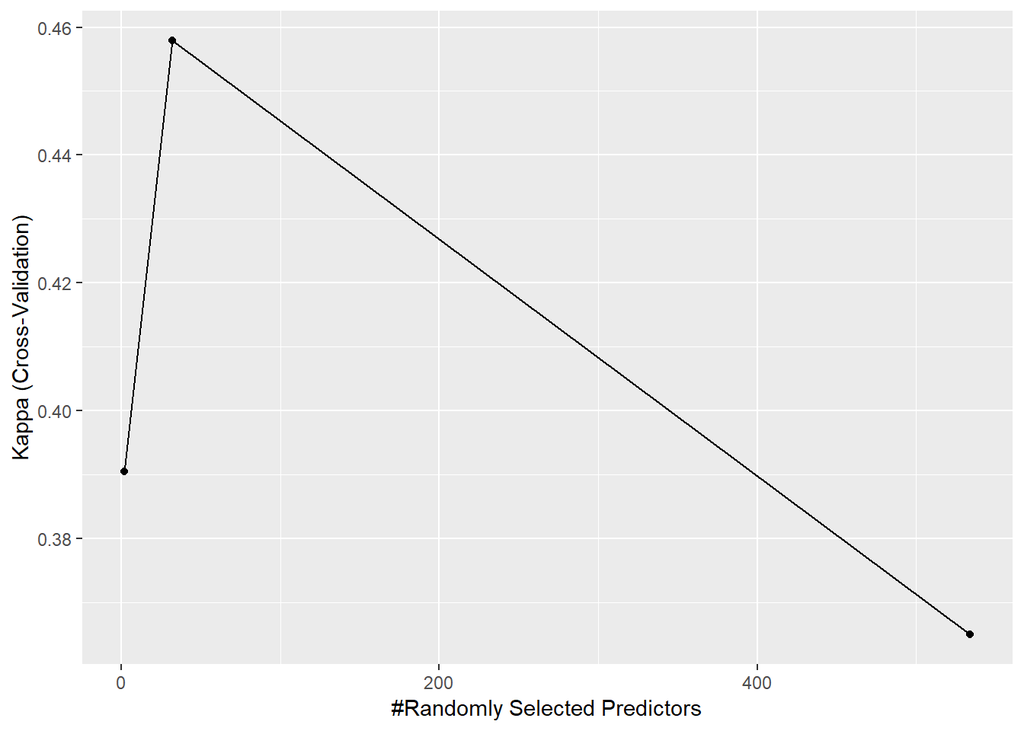

```r
overall_results[["Y_ALL"]][["random_forest"]][["graph"]]
```

See the “variable” `importance`, for a given year and Random Forest (from these three models, only Random Forests provide `importance`):

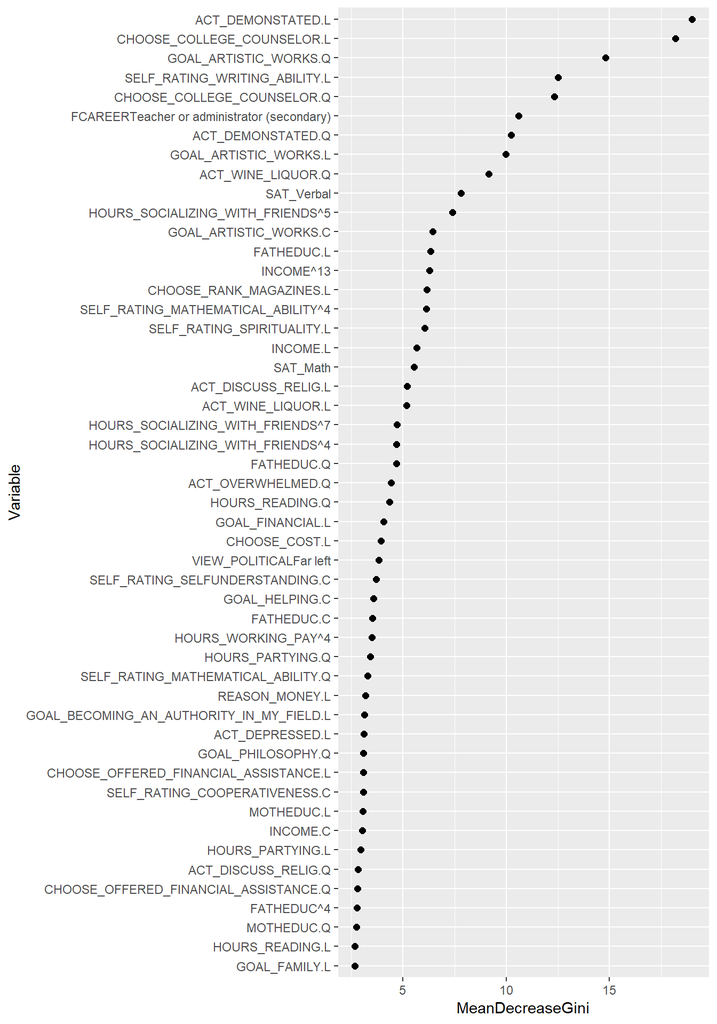

```r
overall_results[["Y_ALL"]][["random_forest"]][["importance"]]
```

See the “test” `roc`, for a given year and Random Forest:

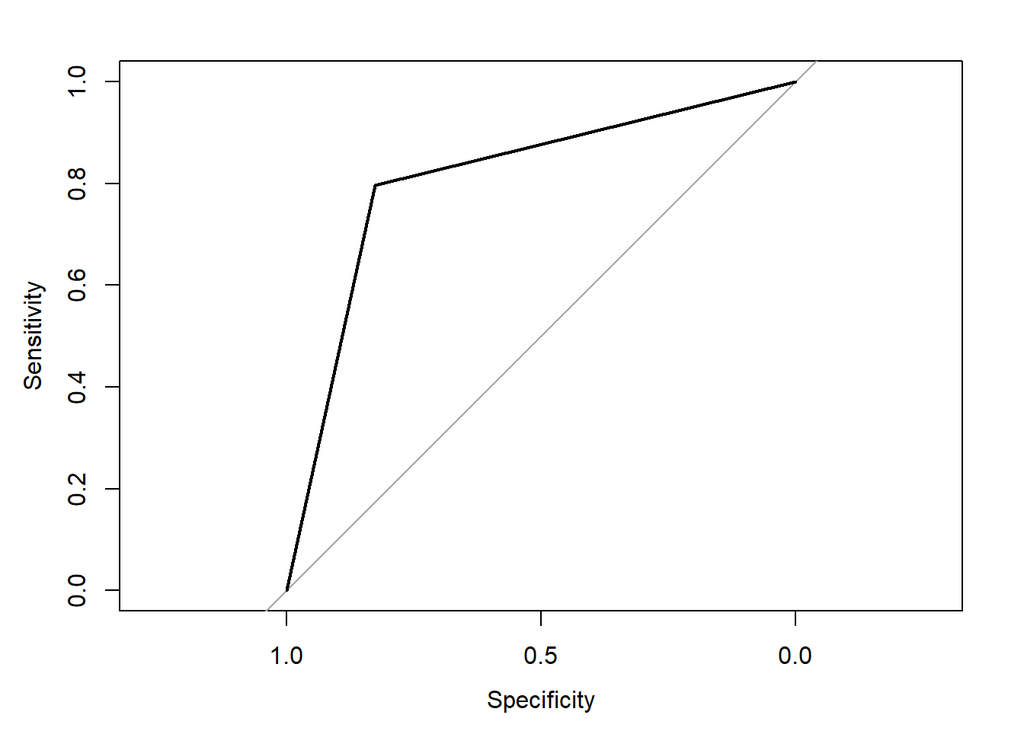

```
##
## Call:
## plot.roc.default(x = as.numeric(predictions), predictor = as.numeric(data[,     dependent]))
##
## Data: as.numeric(data[, dependent]) in 69 controls (as.numeric(predictions) 1) < 152 cases (as.numeric(predictions) 2).
## Area under the curve: 0.8111
```

```r
predictor <- overall_results[["Y_ALL"]][["random_forest"]][["predictor"]]
roc(predictor, data[["test"]], "SAT_OVERALL")
```